# Codebook for durhamdata

Autogenerated data summary from dataReporter

2024-04-03 11:59:23.901792

# Data report overview

The dataset examined has the following dimensions:

| Feature | Result |
| --- | --- |
| Number of observations | 326024 |
| Number of variables | 18 |

# Codebook summary table

| Label | Variable | Class | # unique values | Missing | Description |
| --- | --- | --- | --- | --- | --- |
|  | **date** | Date | 5112 | 0.00 % | The date of the stop, in YYYY-MM-DD format. |
|  | **time** | hms | 57163 | 14.80 % | The 24-hour time of the stop, in HH:MM format. |
|  | **location** | character | 96 | 0.00 % | City and county |
|  | **county_name** | character | 12 | 0.00 % |  |
|  | **subject_age** | integer | 90 | 0.00 % | The age of the stopped subject. When date of birth is given, we calculate the age based on the stop date. |
|  | **subject_race** | factor | 7 | 0.00 % | The race of the stopped subject. Values are standardized to white, black, hispanic, asian/pacific islander, and other/unknown |
|  | **subject_sex** | factor | 3 | 0.00 % | The recorded sex of the stopped subject. |
|  | **department_name** | character | 2 | 0.00 % | Name of department or subdivision to which officer has been assigned. |
|  | **type** | factor | 1 | 0.00 % | Type of stop: vehicular or pedestrian |
|  | **arrest_made** | logical | 2 | 0.00 % | Indicates whether an arrest made. |
|  | **citation_issued** | logical | 2 | 0.00 % | Indicates whether a citation was issued. |
|  | **warning_issued** | logical | 2 | 0.00 % | Indicates whether a warning was issued. |
|  | **frisk_performed** | logical | 2 | 0.00 % | Indicates whether a frisk was performed. This is technically different from a search, but departments will sometimes include frisks as a search type. |
|  | **search_conducted** | logical | 2 | 0.00 % | Indicates whether any type of search was conducted, i.e. driver, passenger, vehicle. Frisks are excluded where the department has provided resolution on both. |
|  | **search_basis** | factor | 4 | 93.58 % | This provides the reason for the search where provided and is categorized into k9, plain view, consent, probable cause, and other. If a serach occurred but the reason wasn’t listed, we assume probable… |
|  | **reason_for_frisk** | character | 28 | 99.76 % | A freeform text field indicating the reason for frisk where provided. |
|  | **reason_for_search** | character | 58 | 93.34 % | A freeform text field indicating the reason for search where provided. |
|  | **reason_for_stop** | character | 10 | 0.00 % | A freeform text field indicating the reason for the stop where provided. |

# Variable list

## date

| Feature | Result |
| --- | --- |
| Variable type | Date |
| Number of missing obs. | 0 (0 %) |
| Number of unique values | 5112 |
| Mode | “2010-01-22” |
| Min. and max. | 2001-12-28; 2015-12-31 |
| 1st and 3rd quartiles | 2006-09-24; 2012-10-24 |

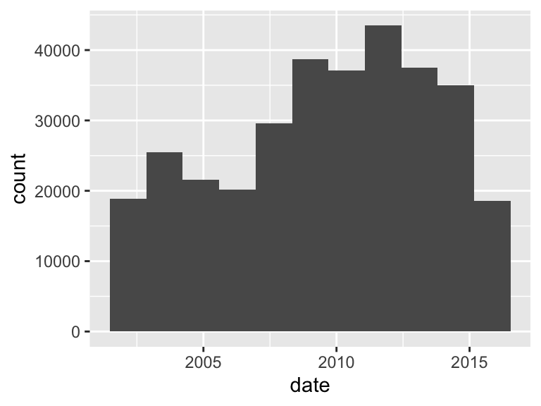

## time

- The variable has class hms which is not supported by dataReporter.

## location

| Feature | Result |
| --- | --- |
| Variable type | character |
| Number of missing obs. | 0 (0 %) |
| Number of unique values | 96 |
| Mode | “nan, Durham County” |

[figure not shown]

## county_name

| Feature | Result |
| --- | --- |
| Variable type | character |
| Number of missing obs. | 0 (0 %) |
| Number of unique values | 12 |
| Mode | “Durham County” |

[figure not shown]

- Observed factor levels: "Beaufort County", "Brunswick County", "Dare County", "Davidson County", "Davie County", "Duplin County", "Durham County", "Macon County", "Orange County", "Scotland County", "Union County", "Vance County".

## subject_age

| Feature | Result |
| --- | --- |
| Variable type | integer |
| Number of missing obs. | 7 (0 %) |
| Number of unique values | 89 |
| Median | 32 |
| 1st and 3rd quartiles | 25; 43 |
| Min. and max. | 10; 99 |

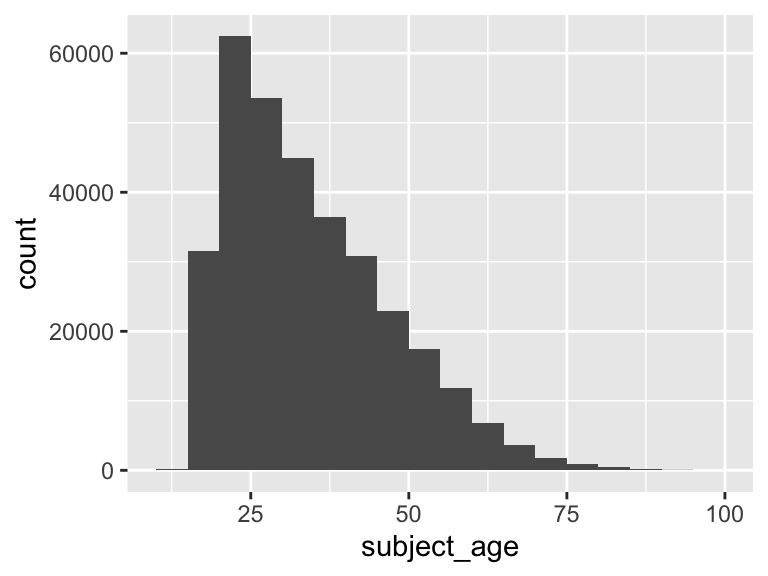

## subject_race

| Feature | Result |
| --- | --- |
| Variable type | factor |
| Number of missing obs. | 1 (0 %) |
| Number of unique values | 6 |
| Mode | “black” |
| Reference category | asian/pacific islander |

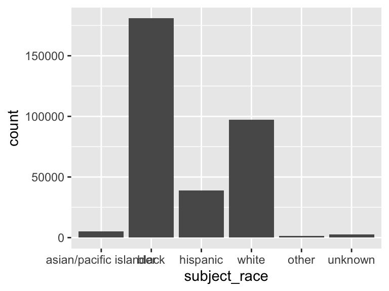

- Observed factor levels: "asian/pacific islander", "black", "hispanic", "other", "unknown", "white".

## subject_sex

| Feature | Result |
| --- | --- |
| Variable type | factor |
| Number of missing obs. | 1 (0 %) |
| Number of unique values | 2 |
| Mode | “male” |
| Reference category | male |

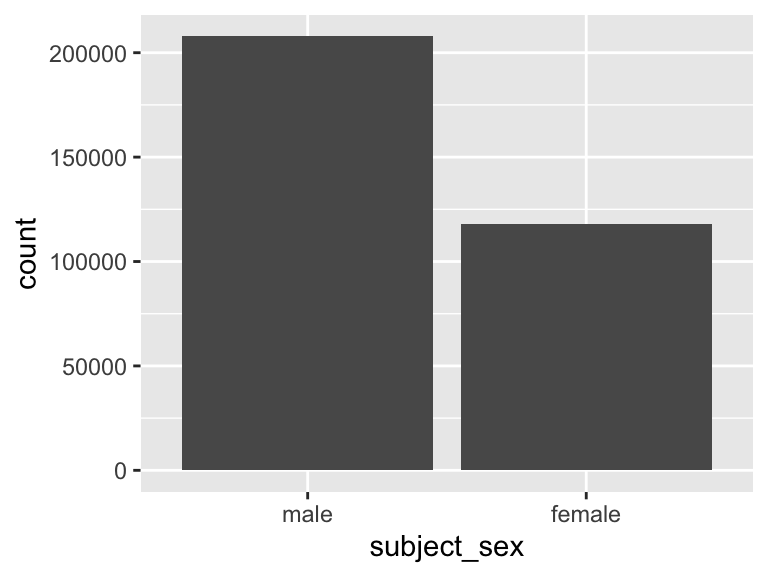

- Observed factor levels: "female", "male".

## department_name

| Feature | Result |
| --- | --- |
| Variable type | character |
| Number of missing obs. | 0 (0 %) |
| Number of unique values | 2 |
| Mode | “Durham Police Department” |

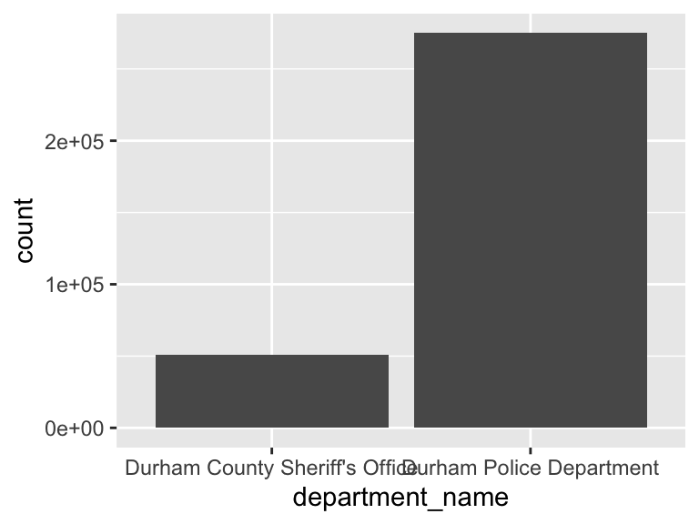

- Observed factor levels: "Durham County Sheriff’s Office", "Durham Police Department".

## type

- The variable only takes one (non-missing) value: "vehicular". The variable contains 0 % missing observations.

## arrest_made

| Feature | Result |
| --- | --- |
| Variable type | logical |
| Number of missing obs. | 0 (0 %) |
| Number of unique values | 2 |
| Mode | “FALSE” |

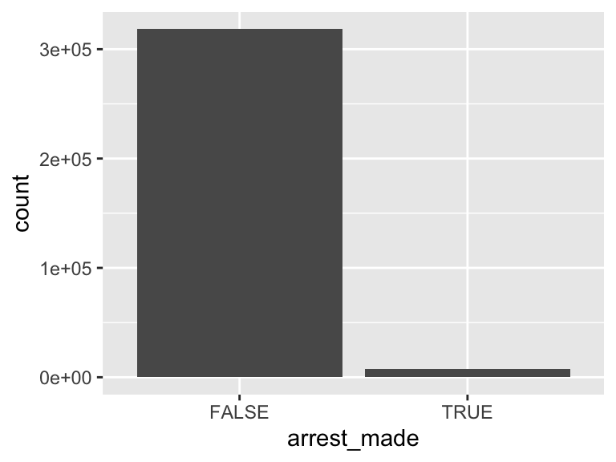

## citation_issued

| Feature | Result |
| --- | --- |
| Variable type | logical |
| Number of missing obs. | 0 (0 %) |
| Number of unique values | 2 |
| Mode | “TRUE” |

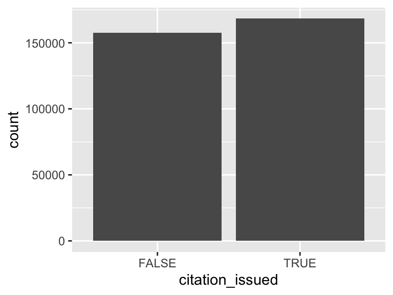

## warning_issued

| Feature | Result |
| --- | --- |
| Variable type | logical |
| Number of missing obs. | 0 (0 %) |
| Number of unique values | 2 |
| Mode | “FALSE” |

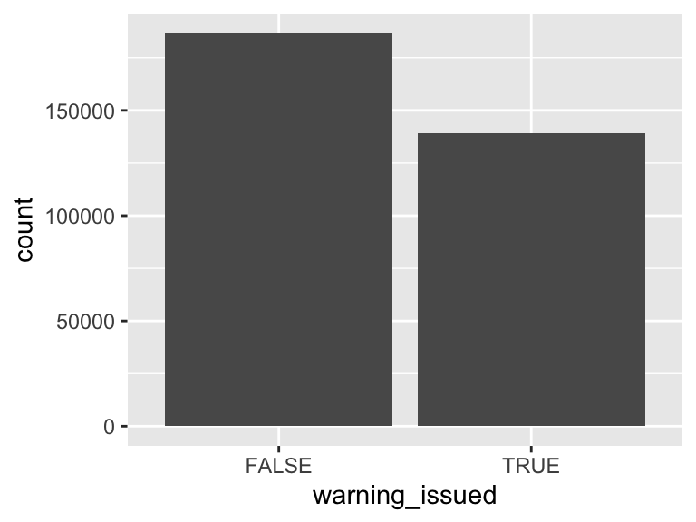

## frisk_performed

| Feature | Result |
| --- | --- |
| Variable type | logical |
| Number of missing obs. | 0 (0 %) |
| Number of unique values | 2 |
| Mode | “FALSE” |

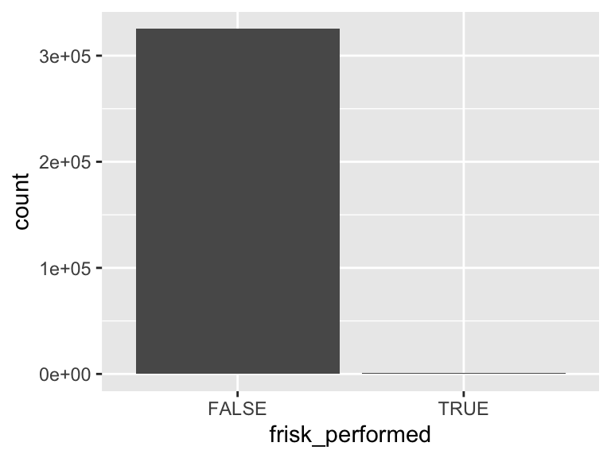

## search_conducted

| Feature | Result |
| --- | --- |
| Variable type | logical |
| Number of missing obs. | 0 (0 %) |
| Number of unique values | 2 |
| Mode | “FALSE” |

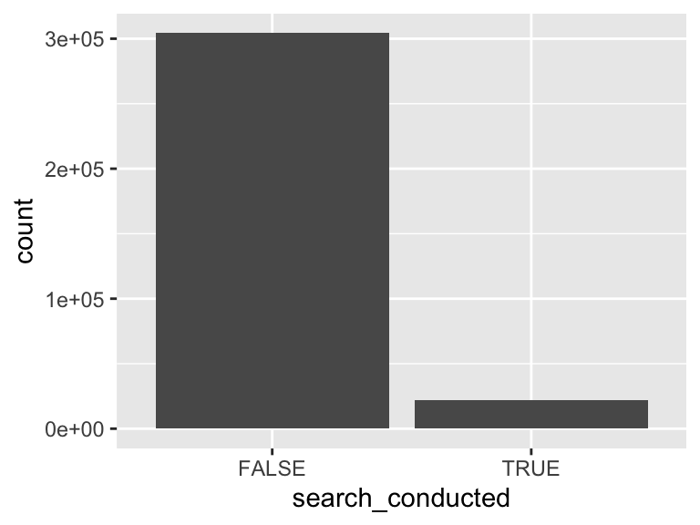

## search_basis

| Feature | Result |
| --- | --- |
| Variable type | factor |
| Number of missing obs. | 305092 (93.58 %) |
| Number of unique values | 3 |
| Mode | “consent” |
| Reference category | k9 |

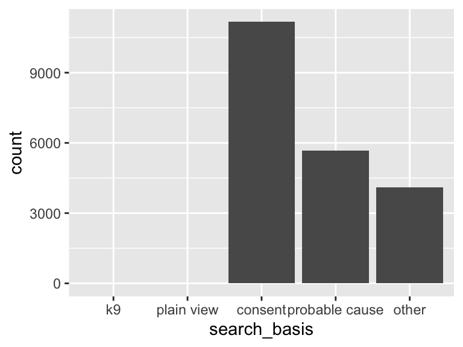

- Observed factor levels: "consent", "k9", "other", "plain view", "probable cause".

## reason_for_frisk

| Feature | Result |
| --- | --- |
| Variable type | character |
| Number of missing obs. | 325250 (99.76 %) |
| Number of unique values | 27 |
| Mode | “Suspicious Movement” |

[figure not shown]

- Observed factor levels: "Erratic/Suspicious Behavior", "Erratic/Suspicious Behavior|Informant Tip", "Erratic/Suspicious Behavior|Informant Tip|Other Official Information", "Erratic/Suspicious Behavior|Observation of Suspected Contraband", "Erratic/Suspicious Behavior|Observation of Suspected Contraband|Informant Tip", "Erratic/Suspicious Behavior|Observation of Suspected Contraband|Suspicious Movement", "Erratic/Suspicious Behavior|Observation of Suspected Contraband|Suspicious Movement|Informant Tip", "Erratic/Suspicious Behavior|Other Official Information", "Erratic/Suspicious Behavior|Other Official Information|Suspicious Movement", "Erratic/Suspicious Behavior|Suspicious Movement", "Erratic/Suspicious Behavior|Suspicious Movement|Informant Tip", "Erratic/Suspicious Behavior|Suspicious Movement|Informant Tip|Other Official Information", "Erratic/Suspicious Behavior|Suspicious Movement|Witness Observation", "Erratic/Suspicious Behavior|Witness Observation", "Informant Tip", "Informant Tip|Witness Observation", "Observation of Suspected Contraband", "Observation of Suspected Contraband|Suspicious Movement", "Observation of Suspected Contraband|Witness Observation", "Other Official Information", "Other Official Information|Suspicious Movement", "Other Official Information|Witness Observation", "Suspicious Movement", "Suspicious Movement|Informant Tip", "Suspicious Movement|Other Official Information", "Suspicious Movement|Witness Observation", "Witness Observation".

## reason_for_search

| Feature | Result |
| --- | --- |
| Variable type | character |
| Number of missing obs. | 304318 (93.34 %) |
| Number of unique values | 57 |
| Mode | “Erratic/Suspicious Behavior” |

[figure not shown]

- Observed factor levels: "Erratic/Suspicious Behavior", "Erratic/Suspicious Behavior|Informant Tip", "Erratic/Suspicious Behavior|Informant Tip|Other Official Information", "Erratic/Suspicious Behavior|Informant Tip|Other Official Information|Witness Observation", "Erratic/Suspicious Behavior|Informant Tip|Witness Observation", "Erratic/Suspicious Behavior|Observation of Suspected Contraband", "Erratic/Suspicious Behavior|Observation of Suspected Contraband|Informant Tip", "Erratic/Suspicious Behavior|Observation of Suspected Contraband|Informant Tip|Other Official Information", "Erratic/Suspicious Behavior|Observation of Suspected Contraband|Informant Tip|Witness Observation", "Erratic/Suspicious Behavior|Observation of Suspected Contraband|Other Official Information", "Erratic/Suspicious Behavior|Observation of Suspected Contraband|Other Official Information|Suspicious Movement", "Erratic/Suspicious Behavior|Observation of Suspected Contraband|Other Official Information|Witness Observation", "Erratic/Suspicious Behavior|Observation of Suspected Contraband|Suspicious Movement", "Erratic/Suspicious Behavior|Observation of Suspected Contraband|Suspicious Movement|Informant Tip", "Erratic/Suspicious Behavior|Observation of Suspected Contraband|Suspicious Movement|Informant Tip|Other Official Information", "Erratic/Suspicious Behavior|Observation of Suspected Contraband|Suspicious Movement|Informant Tip|Other Official Information|Witness Observation", "Erratic/Suspicious Behavior|Observation of Suspected Contraband|Suspicious Movement|Informant Tip|Witness Observation", "Erratic/Suspicious Behavior|Observation of Suspected Contraband|Suspicious Movement|Other Official Information", "Erratic/Suspicious Behavior|Observation of Suspected Contraband|Suspicious Movement|Witness Observation", "Erratic/Suspicious Behavior|Observation of Suspected Contraband|Witness Observation", "Erratic/Suspicious Behavior|Other Official Information", "Erratic/Suspicious Behavior|Other Official Information|Suspicious Movement", "Erratic/Suspicious Behavior|Other Official Information|Witness Observation", "Erratic/Suspicious Behavior|Suspicious Movement", "Erratic/Suspicious Behavior|Suspicious Movement|Informant Tip", "Erratic/Suspicious Behavior|Suspicious Movement|Informant Tip|Other Official Information", "Erratic/Suspicious Behavior|Suspicious Movement|Informant Tip|Other Official Information|Witness Observation", "Erratic/Suspicious Behavior|Suspicious Movement|Informant Tip|Witness Observation", "Erratic/Suspicious Behavior|Suspicious Movement|Other Official Information", "Erratic/Suspicious Behavior|Suspicious Movement|Witness Observation", "Erratic/Suspicious Behavior|Witness Observation", "Informant Tip", "Informant Tip|Other Official Information", "Informant Tip|Witness Observation", "Observation of Suspected Contraband", "Observation of Suspected Contraband|Informant Tip", "Observation of Suspected Contraband|Informant Tip|Other Official Information", "Observation of Suspected Contraband|Informant Tip|Witness Observation", "Observation of Suspected Contraband|Other Official Information", "Observation of Suspected Contraband|Suspicious Movement", "Observation of Suspected Contraband|Suspicious Movement|Informant Tip", "Observation of Suspected Contraband|Suspicious Movement|Other Official Information", "Observation of Suspected Contraband|Suspicious Movement|Witness Observation", "Observation of Suspected Contraband|Witness Observation", "Other Official Information", "Other Official Information|Informant Tip", "Other Official Information|Suspicious Movement", "Other Official Information|Suspicious Movement|Informant Tip", "Other Official Information|Witness Observation", "Suspicious Movement", "Suspicious Movement|Informant Tip", "Suspicious Movement|Informant Tip|Other Official Information", "Suspicious Movement|Informant Tip|Witness Observation", "Suspicious Movement|Other Official Information", "Suspicious Movement|Other Official Information|Witness Observation", "Suspicious Movement|Witness Observation", "Witness Observation".

## reason_for_stop

| Feature | Result |
| --- | --- |
| Variable type | character |
| Number of missing obs. | 0 (0 %) |
| Number of unique values | 10 |
| Mode | “Speed Limit Violation” |

[figure not shown]

- Observed factor levels: "Checkpoint", "Driving While Impaired", "Investigation", "Other Motor Vehicle Violation", "Safe Movement Violation", "Seat Belt Violation", "Speed Limit Violation", "Stop Light/Sign Violation", "Vehicle Equipment Violation", "Vehicle Regulatory Violation".

Report generation information:

- Created by: Charlotte Pierce (username: `charlottepierce`).
- Report creation time: Wed Apr 03 2024 11:59:52
- Report was run from directory: `/Users/charlottepierce/Desktop/Spring 2024/R DATA VIZ/GLHLTH562/FinalProject/camden/code`
- dataReporter v1.0.2 [Pkg: 2021-11-11 from CRAN (R 4.3.0)]
- R version 4.3.2 (2023-10-31).
- Platform: x86_64-apple-darwin20 (64-bit)(America/Detroit).
- Function call: `dataReporter::makeDataReport(data = durhamdata, mode = c("summarize", "visualize", "check"), smartNum = FALSE, file = "codebook_durhamdata.Rmd", replace = TRUE, checks = list(character = "showAllFactorLevels", factor = "showAllFactorLevels", labelled = "showAllFactorLevels", haven_labelled = "showAllFactorLevels", numeric = NULL, integer = NULL, logical = NULL, Date = NULL), listChecks = FALSE, maxProbVals = Inf, codebook = TRUE, reportTitle = "Codebook for durhamdata")`